# **iFood Marketing Analysis**

Agbroko Joshua

## **Project Scenario**

I’m a marketing data analyst and I’ve been told by the Chief Marketing Officer of the fictional iFood Company that recent marketing campaigns have not been as effective as they were expected to be. I need to analyze the data set to understand this problem and propose data-driven solutions. In this dataset’s Kaggle page, there are some EDA directions that the data publisher suggested following and I decided to choose some to explore.

## **Dataset Overview**

The dataset for this project is provided by Dr. Omar Romero-Hernandez. It is licensed as CC0: Public Domain, which states, “You can copy, modify, distribute and perform the work, even for commercial purposes, all without asking permission” You can also see the license status and download this dataset on this [Kaggle page](https://www.kaggle.com/jackdaoud/marketing-data).

## **Table of Contents**

### Section 01: Exploratory Data Analysis

- Handling missing values
- Feature engineering
- Do you notice any patterns or anomalies in the data ? Can these be plotted ?

### Section 02: Statistical Analysis

- What factors are significantly related to the number of store purchases?
- My supervisor insists that people who buy gold are more conservative. justify or refute this statement using an appropriate statistical test.
- Fish has Omega 3 fatty acids which are good for the brain. Accordingly, do “Married PhD candidates” have a significant relation with amount spent on fish?

### Section 03: Data Visualization

- Which marketing campaign is more successful
- What does the average customer look like for this company?
- Which products are performing best and Which channels are underperforming

### Section 04: Formulating Data-Driven Solutions

- Bringing together everything to provide data_driven recommendations for my CMO.

Before we dive we need to load the dataset and all required packages for this project.

```r
# load packages
library(tidyverse)
library(readxl)
library(dplyr)
library(cowplot)
library(corrplot)
library(shapley)
library(shapper)
library(ggplot2)
library(stats)
library(reshape2)
library(randomForest)
library(caret)


df <- read_excel("~/R/Pathway Projects/portfolio/Marketing_Analytics-main/marketing_data.xlsx")
```

## **Section 1: Exploratory Data Analysis**

First, we need to get an idea of what the dataset looks like.

### Features Information from Kaggle:

- ID: Customer’s unique identifier
- Year_Birth: Customer’s birth year
- Education: Customer’s education level
- Marital_Status: Customer’s marital status
- Income: Customer’s yearly household income
- Kidhome: Number of children in customer’s household
- Tennhome: Number of teenagers in customer’s household
- Dt_Customer: Date of customer’s enrollment with the company
- Recency: Number of days since customer’s last purchase
- MntWines: Amount spent on wine in the last 2 years
- MntFruits: Amount spent on fruits in the last 2 years
- MntMeatProducts: Amount spent on meat in the last 2 years
- MntFishProducts: Amount spent on fish in the last 2 years
- MntSweetProducts: Amount spent on sweets in the last 2 years
- MntGoldProds: Amount spent on gold in the last 2 years
- NumDealsPurchase: Number of purchases made with a discount
- NumWebPurchase: Number of purchases made through the company’s web site
- NumCatalogPurchase: Number of purchases made using a catalogue
- NumStorePurchase: Number of purchases made directly in stores
- NumWebVisitsMonth: Number of visits to company’s web site in the last month
- AcceptedCmp3: 1 if customer accepted the offer in the 3rd campaign, 0 otherwise
- AcceptedCmp4: 1 if customer accepted the offer in the 4th campaign, 0 otherwise
- AcceptedCmp5: 1 if customer accepted the offer in the 5th campaign, 0 otherwise
- AcceptedCmp1: 1 if customer accepted the offer in the 1st campaign, 0 otherwise
- AcceptedCmp2: 2 if customer accepted the offer in the 1st campaign, 0 otherwise
- Respones: 1 if customer accepted the offer in the last campaign, 0 otherwise
- Complain: 1 if customer complained in the last 2 years, 0 otherwise
- Country: Customer’s location

### Summary

```r
head(df)
```

```
## # A tibble: 6 × 28
##      ID Year_Birth Education  Marital_Status Income Kidhome Teenhome
##   <dbl>      <dbl> <chr>      <chr>           <dbl>   <dbl>    <dbl>
## 1  1826       1970 Graduation Divorced        84835       0        0
## 2     1       1961 Graduation Single          57091       0        0
## 3 10476       1958 Graduation Married         67267       0        1
## 4  1386       1967 Graduation Together        32474       1        1
## 5  5371       1989 Graduation Single          21474       1        0
## 6  7348       1958 PhD        Single          71691       0        0
## # ℹ 21 more variables: Dt_Customer <dttm>, Recency <dbl>, MntWines <dbl>,
## #   MntFruits <dbl>, MntMeatProducts <dbl>, MntFishProducts <dbl>,
## #   MntSweetProducts <dbl>, MntGoldProds <dbl>, NumDealsPurchases <dbl>,
## #   NumWebPurchases <dbl>, NumCatalogPurchases <dbl>, NumStorePurchases <dbl>,
## #   NumWebVisitsMonth <dbl>, AcceptedCmp3 <dbl>, AcceptedCmp4 <dbl>,
## #   AcceptedCmp5 <dbl>, AcceptedCmp1 <dbl>, AcceptedCmp2 <dbl>, Response <dbl>,
## #   Complain <dbl>, Country <chr>
```

```r
basic_info <- function(df) {
  cat("This dataset has", ncol(df), "columns and", nrow(df), "rows.\n")
  cat("This dataset has", nrow(df[duplicated(df), ]), "duplicated rows.\n\n")
  cat("Descriptive statistics of the numeric features in the dataset:\n\n")
  print(summary(df))
  cat("\nInformation about this dataset:\n\n")
  print(str(df))
}
```

```r
basic_info(df)
```

```
## This dataset has 28 columns and 2240 rows.
## This dataset has 0 duplicated rows.
##
## Descriptive statistics of the numeric features in the dataset:
##
##        ID          Year_Birth    Education         Marital_Status
##  Min.   :    0   Min.   :1893   Length:2240        Length:2240
##  1st Qu.: 2828   1st Qu.:1959   Class :character   Class :character
##  Median : 5458   Median :1970   Mode  :character   Mode  :character
##  Mean   : 5592   Mean   :1969
##  3rd Qu.: 8428   3rd Qu.:1977
##  Max.   :11191   Max.   :1996
##
##      Income          Kidhome          Teenhome
##  Min.   :  1730   Min.   :0.0000   Min.   :0.0000
##  1st Qu.: 35303   1st Qu.:0.0000   1st Qu.:0.0000
##  Median : 51382   Median :0.0000   Median :0.0000
##  Mean   : 52247   Mean   :0.4442   Mean   :0.5062
##  3rd Qu.: 68522   3rd Qu.:1.0000   3rd Qu.:1.0000
##  Max.   :666666   Max.   :2.0000   Max.   :2.0000
##  NA's   :24
##   Dt_Customer                        Recency         MntWines
##  Min.   :2012-07-30 00:00:00.00   Min.   : 0.00   Min.   :   0.00
##  1st Qu.:2013-01-16 00:00:00.00   1st Qu.:24.00   1st Qu.:  23.75
##  Median :2013-07-08 12:00:00.00   Median :49.00   Median : 173.50
##  Mean   :2013-07-10 10:01:42.85   Mean   :49.11   Mean   : 303.94
##  3rd Qu.:2013-12-30 06:00:00.00   3rd Qu.:74.00   3rd Qu.: 504.25
##  Max.   :2014-06-29 00:00:00.00   Max.   :99.00   Max.   :1493.00
##
##    MntFruits     MntMeatProducts  MntFishProducts  MntSweetProducts
##  Min.   :  0.0   Min.   :   0.0   Min.   :  0.00   Min.   :  0.00
##  1st Qu.:  1.0   1st Qu.:  16.0   1st Qu.:  3.00   1st Qu.:  1.00
##  Median :  8.0   Median :  67.0   Median : 12.00   Median :  8.00
##  Mean   : 26.3   Mean   : 166.9   Mean   : 37.53   Mean   : 27.06
##  3rd Qu.: 33.0   3rd Qu.: 232.0   3rd Qu.: 50.00   3rd Qu.: 33.00
##  Max.   :199.0   Max.   :1725.0   Max.   :259.00   Max.   :263.00
##
##   MntGoldProds    NumDealsPurchases NumWebPurchases  NumCatalogPurchases
##  Min.   :  0.00   Min.   : 0.000    Min.   : 0.000   Min.   : 0.000
##  1st Qu.:  9.00   1st Qu.: 1.000    1st Qu.: 2.000   1st Qu.: 0.000
```

[output cut: 47 more lines]

```
##  $ MntGoldProds       : num [1:2240] 218 37 30 0 34 43 65 7 5 5 ...
##  $ NumDealsPurchases  : num [1:2240] 1 1 1 1 2 1 1 1 3 3 ...
##  $ NumWebPurchases    : num [1:2240] 4 7 3 1 3 4 10 2 6 6 ...
##  $ NumCatalogPurchases: num [1:2240] 4 3 2 0 1 7 10 1 2 2 ...
##  $ NumStorePurchases  : num [1:2240] 6 7 5 2 2 5 7 3 9 9 ...
##  $ NumWebVisitsMonth  : num [1:2240] 1 5 2 7 7 2 6 5 4 4 ...
##  $ AcceptedCmp3       : num [1:2240] 0 0 0 0 1 0 1 0 0 0 ...
##  $ AcceptedCmp4       : num [1:2240] 0 0 0 0 0 0 0 0 0 0 ...
##  $ AcceptedCmp5       : num [1:2240] 0 0 0 0 0 0 0 0 0 0 ...
##  $ AcceptedCmp1       : num [1:2240] 0 0 0 0 0 0 0 0 0 0 ...
##  $ AcceptedCmp2       : num [1:2240] 0 1 0 0 0 0 0 0 0 0 ...
##  $ Response           : num [1:2240] 1 1 0 0 1 1 1 0 0 0 ...
##  $ Complain           : num [1:2240] 0 0 0 0 0 0 0 0 0 0 ...
##  $ Country            : chr [1:2240] "SP" "CA" "US" "AUS" ...
## NULL
```

### Handling missing values

- The ‘Income’ column has 24 missing values which we will impute with 0.

```r
df <- df %>%
  mutate(Income = ifelse(is.na(Income), 0, Income))
```

### Section 1.1: Checking for outliers

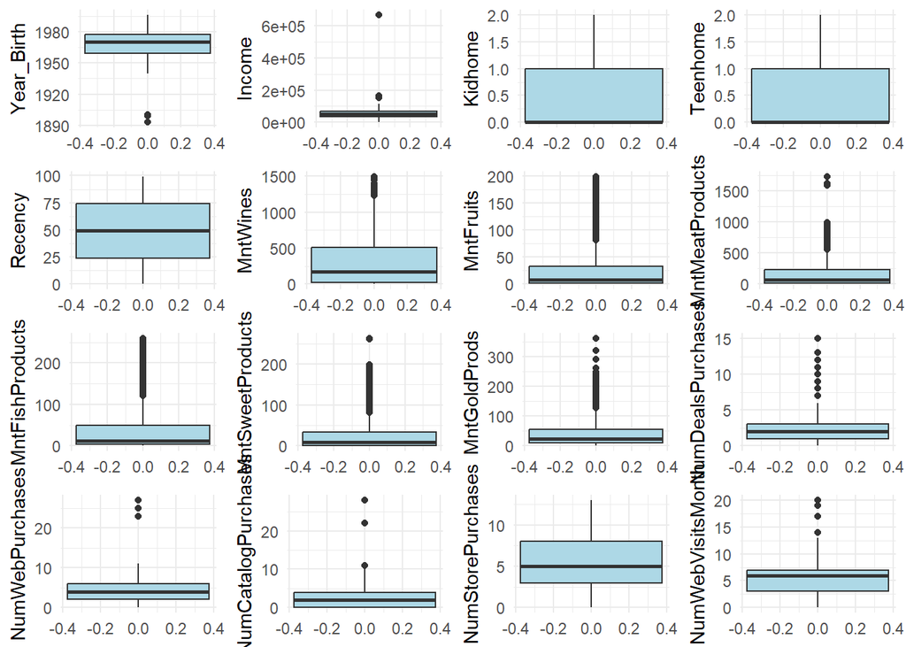

```r
# Selecting columns to plot
df_to_plot <- df %>%
  select(-c(ID, AcceptedCmp1, AcceptedCmp2, AcceptedCmp3, AcceptedCmp4, AcceptedCmp5, Response, Complain)) %>%
  select_if(is.numeric)

# Defining the number of rows and columns for subplots
num_cols <- 4
num_rows <- ceiling(ncol(df_to_plot) / num_cols)

# Creating a list of boxplot objects
boxplots <- lapply(names(df_to_plot), function(col_name) {
  ggplot(df_to_plot, aes_string(y = col_name)) +
    geom_boxplot(fill = "lightblue") +
    labs(y = col_name) +
    theme_minimal()
})

# Arranging  the boxplots in a grid layout
plot_grid(plotlist = boxplots, ncol = num_cols)
```

```r
# Save the plot as an image file
ggsave("boxplots.png", width = 12, height = 14)
```

### Section 1.2: Feature Engineering

```r
 # Creating new features
new_df <- df %>%
  mutate(Join_year = lubridate::year(Dt_Customer),
         Join_month = lubridate::month(Dt_Customer),
         Join_weekday = lubridate::wday(Dt_Customer),
         Minorhome = Kidhome + Teenhome,
         Total_Mnt = MntWines + MntFruits + MntMeatProducts + MntFishProducts + MntSweetProducts + MntGoldProds,
         Total_num_purchase = NumDealsPurchases + NumWebPurchases + NumCatalogPurchases + NumStorePurchases + NumWebVisitsMonth,
         Total_accept = AcceptedCmp1 + AcceptedCmp2 + AcceptedCmp2 + AcceptedCmp2 + AcceptedCmp3 + AcceptedCmp4 + AcceptedCmp5 + Response,
         AOV = Total_Mnt / Total_num_purchase)



# Displaying the first 6 rows
head(new_df)
```

```
## # A tibble: 6 × 36
##      ID Year_Birth Education  Marital_Status Income Kidhome Teenhome
##   <dbl>      <dbl> <chr>      <chr>           <dbl>   <dbl>    <dbl>
## 1  1826       1970 Graduation Divorced        84835       0        0
## 2     1       1961 Graduation Single          57091       0        0
## 3 10476       1958 Graduation Married         67267       0        1
## 4  1386       1967 Graduation Together        32474       1        1
## 5  5371       1989 Graduation Single          21474       1        0
## 6  7348       1958 PhD        Single          71691       0        0
## # ℹ 29 more variables: Dt_Customer <dttm>, Recency <dbl>, MntWines <dbl>,
## #   MntFruits <dbl>, MntMeatProducts <dbl>, MntFishProducts <dbl>,
## #   MntSweetProducts <dbl>, MntGoldProds <dbl>, NumDealsPurchases <dbl>,
## #   NumWebPurchases <dbl>, NumCatalogPurchases <dbl>, NumStorePurchases <dbl>,
## #   NumWebVisitsMonth <dbl>, AcceptedCmp3 <dbl>, AcceptedCmp4 <dbl>,
## #   AcceptedCmp5 <dbl>, AcceptedCmp1 <dbl>, AcceptedCmp2 <dbl>, Response <dbl>,
## #   Complain <dbl>, Country <chr>, Join_year <dbl>, Join_month <dbl>, …
```

```r
# Converting Dt_Customer to date format
new_df$Dt_Customer <- as.Date(new_df$Dt_Customer)
```

## Section 1.3: Do you notice any patterns or anomalies in the data ? Can these be plotted ?

I will use a Heatmap to show the correlations between each variable. When it gets bluer, it means they are positively correlated and when it gets redder, then they are negatively correlated.

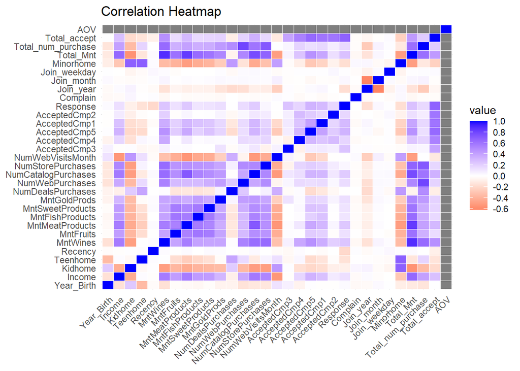

```r
# Selecting numeric columns to plot
df_to_plot <- new_df[, sapply(new_df, is.numeric)]
# Remove the 'ID' column if it exists
df_to_plot <- df_to_plot[, !(names(df_to_plot) %in% c("ID"))]

# Compute correlation matrix
correlation_matrix <- cor(df_to_plot)

# Convert correlation matrix to long format
cor_df <- melt(correlation_matrix)

# Create heatmap plot
ggplot(cor_df, aes(Var1, Var2, fill = value)) +
  geom_tile(color = "white") +
  scale_fill_gradient2(low = "red", mid = "white", high = "blue", midpoint = 0,
                       breaks = seq(-1, 1, by = 0.2)) +
  theme_minimal() +
  theme(axis.text.x = element_text(angle = 45, hjust = 1)) +
  labs(title = "Correlation Heatmap", x = NULL, y = NULL)
```

## Findings:

### Anomaly:

Intuitively, It seems that customers who file more complaints would spend less at our store. However, surprisingly, the number of complaints in the last two years shows almost no correlation with the total amount spent during the same period.

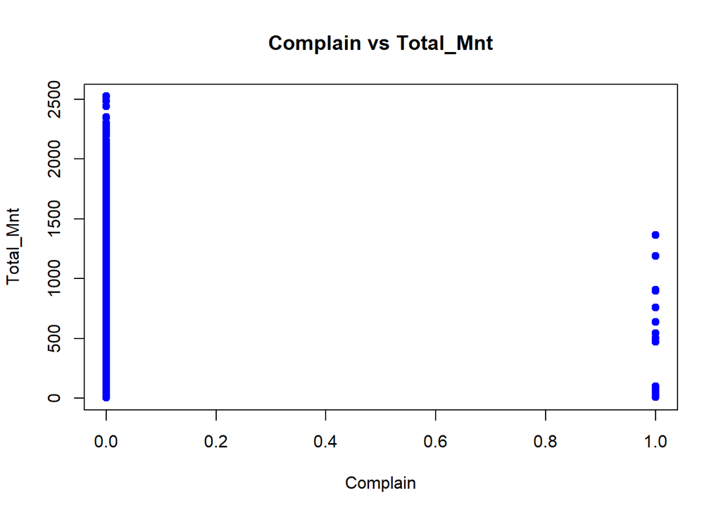

```r
# Visualizing NumWebPurchases vs NumWebVisitsMonth
plot(new_df$Complain, new_df$Total_Mnt,
     xlab = "Complain", ylab = "Total_Mnt",
     main = "Complain vs Total_Mnt",
     col = "blue", pch = 19)
```

# **Section 02: Statistical Analysis**

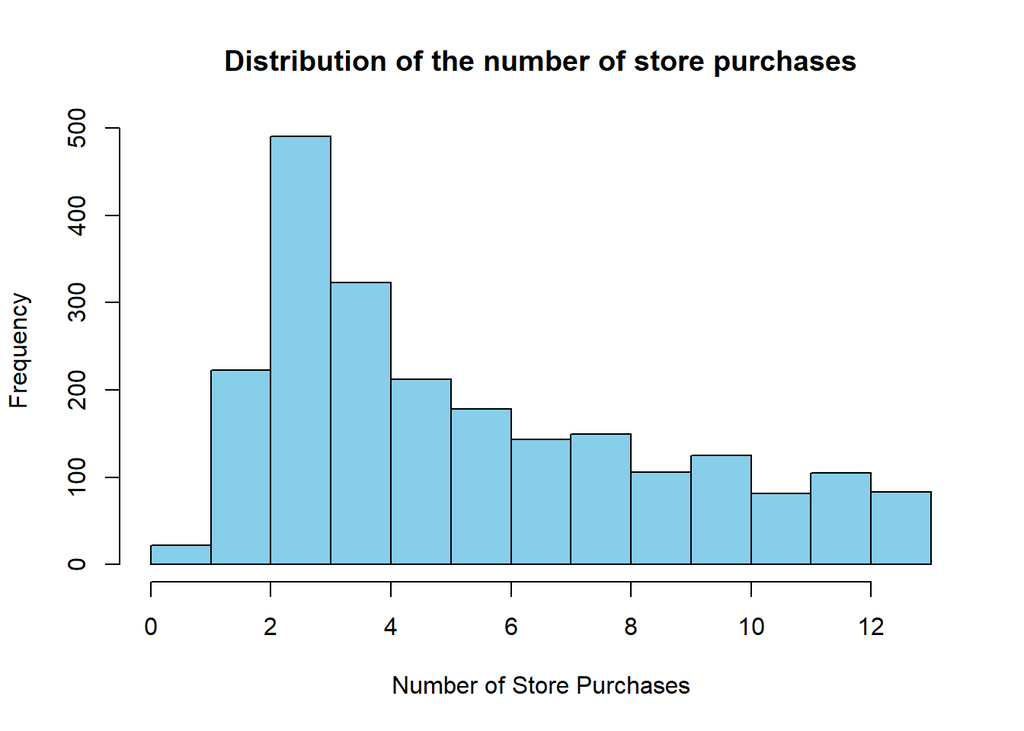

```r
# Create a histogram of NumStorePurchases
hist(new_df$NumStorePurchases,
     main = "Distribution of the number of store purchases",
     xlab = "Number of Store Purchases",
     ylab = "Frequency",
     col = "skyblue",
     border = "black")
```

## Section 2-1: What factors are significantly related to the number of store purchases?

We can use random forest to predict the number of store purchases and then use the model’s feature importance score to rank the factors.

```r
# Drop ID and Dt_Customer columns
rd_df <- new_df[, !(names(new_df) %in% c("ID", "Dt_Customer"))]


# One-hot encoding
rd_df <- dummyVars("~.", data = rd_df) %>%
  predict(rd_df)
# Split dataset into features (X) and labels (y)
X <- subset(rd_df, select = -NumStorePurchases)
y <- rd_df[, "NumStorePurchases", drop = FALSE]



# Split dataset into training set and test set
set.seed(123) # for reproducibility
trainIndex <- createDataPartition(y, p = 0.7, list = FALSE)
X_train <- X[trainIndex, ]
X_test <- X[-trainIndex, ]
y_train <- y[trainIndex]
y_test <- y[-trainIndex]

# Replace infinite values with zero in X_train
X_train[is.infinite(X_train)] <- 0

# Create a Random Forest model
rg <- randomForest(X_train, y_train, ntree = 200)

# Predict on the test set
y_pred <- predict(rg, X_test)

# Calculate evaluation metrics
mae <- mean(abs(y_test - y_pred))
mse <- mean((y_test - y_pred)^2)
rmse <- sqrt(mean((y_test - y_pred)^2))

# Print evaluation metrics
cat("Mean Absolute Error:", mae, "\n")
```

```
## Mean Absolute Error: 0.8754266
```

```r
cat("Mean Squared Error:", mse, "\n")
```

```
## Mean Squared Error: 1.653488
```

```r
cat("Root Mean Squared Error:", rmse, "\n")
```

```
## Root Mean Squared Error: 1.28588
```

Overall, these evaluation metrics suggest that the Random Forest model has performed reasonably well, with relatively low errors compared to the scale of the response variable.

Now let’s use Random Forest’s feature importance score to see which factors most contribute to the NumStorePurchase

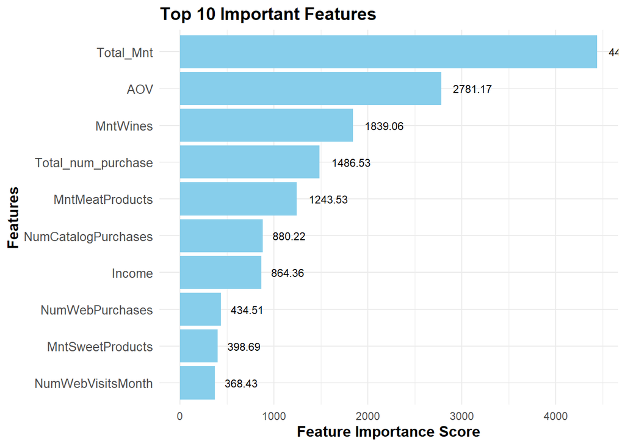

```r
# Get feature importance scores
feature_imp <- importance(rg)
feature_imp <- as.data.frame(feature_imp)
feature_imp$Feature <- rownames(feature_imp)
colnames(feature_imp) <- c("Importance", "Feature")
feature_imp <- feature_imp %>% arrange(desc(Importance))

# Select top 10 important features
top_10_features <- head(feature_imp, 10)

# Create bar plot
ggplot(top_10_features, aes(x = reorder(Feature, Importance), y = Importance)) +
  geom_bar(stat = "identity", fill = "skyblue") +
  coord_flip() +
  labs(x = "Features", y = "Feature Importance Score", title = "Top 10 Important Features") +
  theme_minimal() +
  theme(axis.text.y = element_text(size = 10)) +  # Adjust font size
  theme(axis.title.y = element_text(size = 12, face = "bold")) +  # Adjust font size and style
  theme(axis.title.x = element_text(size = 12, face = "bold")) +  # Adjust font size and style
  theme(plot.title = element_text(size = 14, face = "bold")) +  # Adjust font size and style
  geom_text(aes(label = round(Importance, 2)), hjust = -0.3, size = 3)  # Add labels to bars
```

We can now see that the top 7 factors impacting the Number of store purchases are;

1. Total amount spent in the last two years
2. Average order volume
3. Amount spent on wine in the last 2 years
4. Total number of purchases in the last two years
5. Amount spent on meat in the last 2 years
6. Number of purchases made using a catalog
7. Customer’s yearly household income

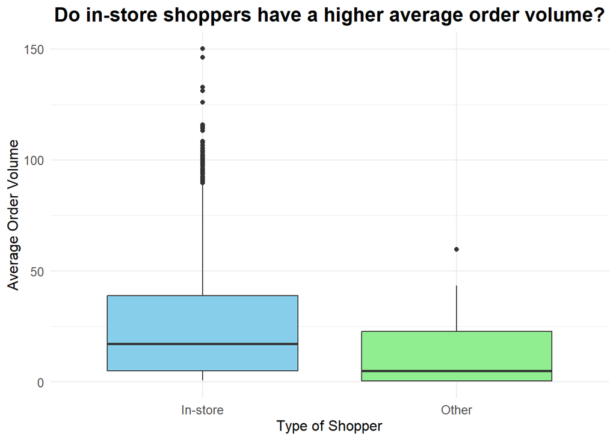

```r
# Filtering store shoppers
store_shoppers <- subset(new_df, NumStorePurchases > 0)
store_shoppers <- subset(store_shoppers, AOV <= (mean(store_shoppers$AOV) + 3 * sd(store_shoppers$AOV)))
store_shoppers$`Type of shopper` <- "In-store"

# Filtering other shoppers
other_shoppers <- subset(new_df, NumStorePurchases == 0)
other_shoppers$`Type of shopper` <- "Other"

# Combining both types of shoppers
all_shoppers <- rbind(store_shoppers, other_shoppers)

# Creating boxplot
library(ggplot2)
ggplot(all_shoppers, aes(x = `Type of shopper`, y = AOV, fill = `Type of shopper`)) +
  geom_boxplot() +
  labs(title = "Do in-store shoppers have a higher average order volume?",
       x = "Type of Shopper",
       y = "Average Order Volume") +
  theme_minimal() +
  theme(plot.title = element_text(size = 16, face = "bold"),
        axis.title = element_text(size = 12),
        axis.text = element_text(size = 10),
        legend.position = "none") +
  scale_fill_manual(values = c("In-store" = "skyblue", "Other" = "lightgreen")) +
  theme(legend.title = element_blank()) +
  theme(plot.title = element_text(hjust = 0.5))
```

## Section 2.2: My supervisor insists that people who buy gold are more conservative. Therefore, people who spent an above average amount on gold in the last 2 years would have more in store purchases. Justify or refute this statement using an appropriate statistical test

Yes, they are statistically significant in that they are positively correlated

To statistically verify this claim, we need to use a correlation test to see if MntGoldProds and NumStorePurchases are positively correlated. We do that by first looking at the scatterplot of the two variables.

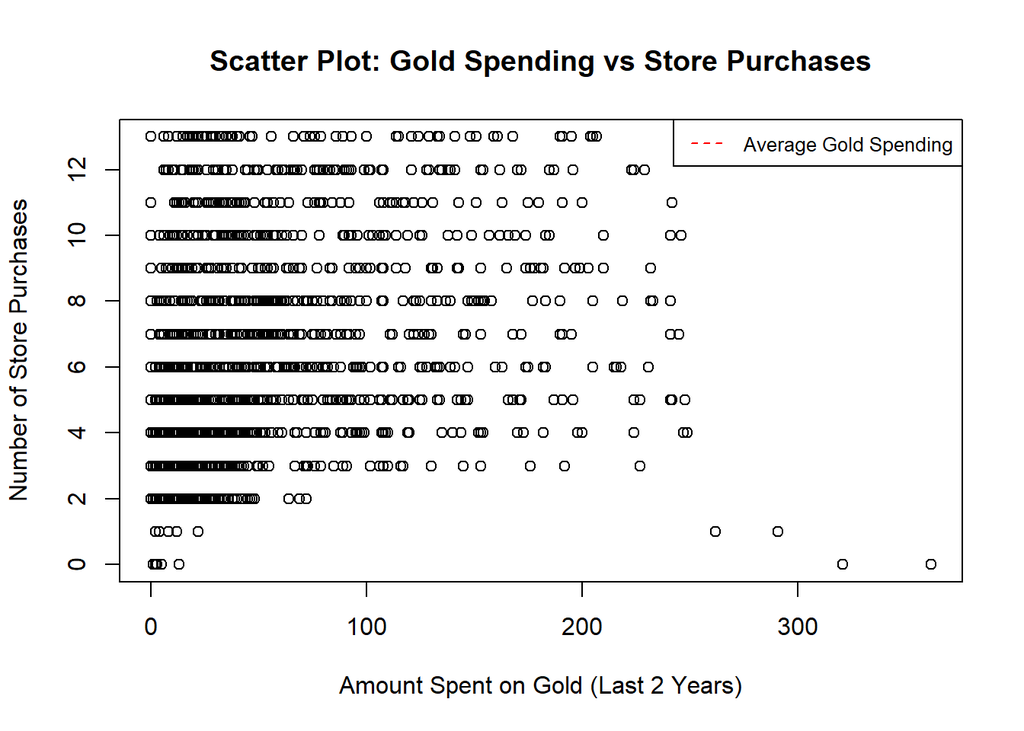

```r
# Calculate average amount spent on gold
average_gold_spent <- mean(new_df$MntGoldProds)

# Create a scatter plot
plot(new_df$MntGoldProds, new_df$NumStorePurchases,
     xlab = "Amount Spent on Gold (Last 2 Years)",
     ylab = "Number of Store Purchases",
     main = "Scatter Plot: Gold Spending vs Store Purchases")

# Add a horizontal line at the average gold spending
abline(h = average_gold_spent, col = "red", lty = 2)

# Add a legend
legend("topright", legend = c("Average Gold Spending"), col = c("red"), lty = 2, cex = 0.8)
```

As shown above, there is a very vague trend that says as Amount Spent on Gold in last years increases, Number of Store Purchases also increases. Now let;s look at the correlation test

```r
# Calculate correlation coefficient
correlation <- cor(new_df$MntGoldProds, new_df$NumStorePurchases)
cat("Correlation coefficient:", correlation, "\n")
```

```
## Correlation coefficient: 0.381678
```

```r
# Perform correlation test
correlation_test <- cor.test(new_df$MntGoldProds, new_df$NumStorePurchases)

# Print the results
print(correlation_test)
```

```
##
##  Pearson's product-moment correlation
##
## data:  new_df$MntGoldProds and new_df$NumStorePurchases
## t = 19.535, df = 2238, p-value < 2.2e-16
## alternative hypothesis: true correlation is not equal to 0
## 95 percent confidence interval:
##  0.3457273 0.4165099
## sample estimates:
##      cor
## 0.381678
```

Based on these results, we can conclude that there is a statistically significant positive correlation between the amount spent on gold and the number of store purchases. The p-value being extremely small suggests that the observed correlation is highly unlikely to have occurred by random chance alone. Therefore, we reject the null hypothesis and conclude that there is a significant relationship between these two variables.

## Section 2.3. Fish has Omega 3 fatty acids which are good for the brain. Accordingly, do “Married PhD candidates” have a significant relation with amount spent on fish?

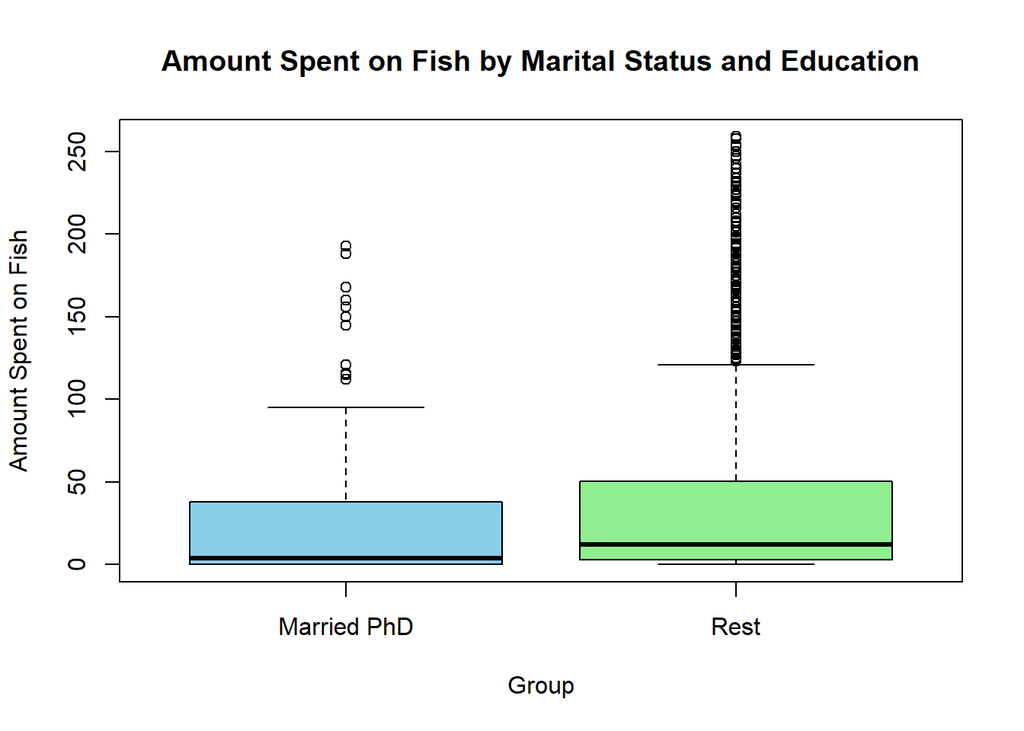

```r
# Divide the data into two groups: married PhD candidates and the rest
married_phd <- new_df[new_df$Marital_Status == "Married" & new_df$Education == "PhD", "MntFishProducts"]
rest <- new_df[!(new_df$Marital_Status == "Married" & new_df$Education == "PhD"), "MntFishProducts"]

# Extract numeric vectors from tibbles
married_phd <- married_phd$MntFishProducts
rest <- rest$MntFishProducts


# Creating a boxplot to visualize the distribution of amount spent on fish for the two groups
boxplot(married_phd, rest,
        names = c("Married PhD", "Rest"),
        xlab = "Group",
        ylab = "Amount Spent on Fish",
        main = "Amount Spent on Fish by Marital Status and Education",
        col = c("skyblue", "lightgreen"))
```

This plot shows that the rest of the customers spent more on fish products as its 50th percentile is higher than the married Ph.D. group. Now, let’s look at the t-test.

```r
# Performing t-test
t_test_result <- t.test(married_phd, rest)
print(t_test_result)
```

```
##
##  Welch Two Sample t-test
##
## data:  married_phd and rest
## t = -3.5151, df = 258.2, p-value = 0.0005191
## alternative hypothesis: true difference in means is not equal to 0
## 95 percent confidence interval:
##  -17.934886  -5.055348
## sample estimates:
## mean of x mean of y
##  27.01562  38.51074
```

These results suggest that there is a statistically significant difference in the mean amount spent on fish between married PhD candidates and the rest of the individuals. Married PhD candidates tend to spend less on fish compared to the rest of the group.

## **Section 03: Data Visualization and Further Analysis**

Here are the questions that I’ll be exploring using data visualization:

- Which marketing campaign is most successful?
- What does the average customer look like for this company? Which products are performing best?
- Investigate the differences in the customer characteristics and purchases behaviors between the most successful campaign and the rest.

Now let’s look at the questions one by one.

### 3.1 Which marketing campaign is most succesful ?

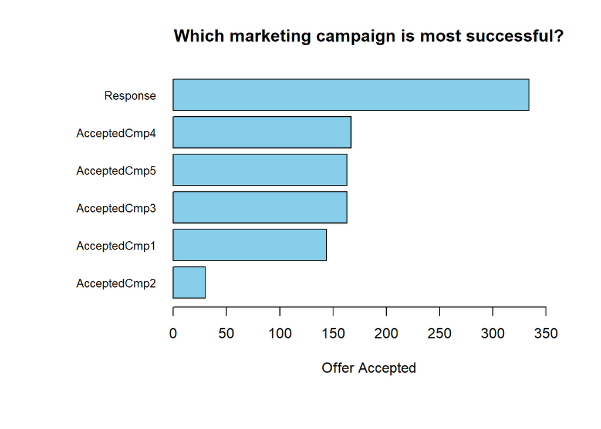

```r
# Calculating  the sum of each marketing campaign
campaign_sum <- colSums(new_df[c("AcceptedCmp1", "AcceptedCmp2", "AcceptedCmp3", "AcceptedCmp4", "AcceptedCmp5", "Response")])

# Sorting the values in ascending order
campaign_sum <- sort(campaign_sum, decreasing =  FALSE)

par(mar = c(7, 10, 4, 2) + 0.1)

# Creating a horizontal bar plot
barplot(campaign_sum,
        horiz = TRUE, # Horizontal bar plot
        main = "Which marketing campaign is most successful?",
        xlab = "Offer Accepted",

        col = "skyblue",
        las = 1,
        xlim = c(0, max(campaign_sum) * 1.1),
        cex.names = 0.8)
```

Response means the last marketing campaign is the most successful one. It performed nearly twice as well as the previous campaigns, except campaign 2.

### 3.2 What does the average customer look like for this company? Which products are performing best?

```r
# Replace infinite values with zero
new_df <- new_df %>%
  mutate_all(~ifelse(is.infinite(.), 0, .))

# Excluding non-numeric columns
numeric_df <- new_df[, sapply(new_df, is.numeric)]

# Calculating the mean of all numeric items in the dataset
mean_values <- colMeans(numeric_df)


# Format the mean values for better readability
formatted_mean_values <- format(mean_values, scientific = FALSE)

# Displaying the mean values
cat("This is what an average customer looks like:\n")
```

```
## This is what an average customer looks like:
```

```r
print(formatted_mean_values)
```

```
##                  ID          Year_Birth              Income             Kidhome
##    " 5592.15982143"    " 1968.80580357"    "51687.45937500"    "    0.44419643"
##            Teenhome         Dt_Customer             Recency            MntWines
##    "    0.50625000"    "15896.41785714"    "   49.10937500"    "  303.93571429"
##           MntFruits     MntMeatProducts     MntFishProducts    MntSweetProducts
##    "   26.30223214"    "  166.95000000"    "   37.52544643"    "   27.06294643"
##        MntGoldProds   NumDealsPurchases     NumWebPurchases NumCatalogPurchases
##    "   44.02187500"    "    2.32500000"    "    4.08482143"    "    2.66205357"
##   NumStorePurchases   NumWebVisitsMonth        AcceptedCmp3        AcceptedCmp4
##    "    5.79017857"    "    5.31651786"    "    0.07276786"    "    0.07455357"
##        AcceptedCmp5        AcceptedCmp1        AcceptedCmp2            Response
##    "    0.07276786"    "    0.06428571"    "    0.01339286"    "    0.14910714"
##            Complain           Join_year          Join_month        Join_weekday
##    "    0.00937500"    " 2013.02812500"    "    6.46741071"    "    4.02723214"
##           Minorhome           Total_Mnt  Total_num_purchase        Total_accept
##    "    0.95044643"    "  605.79821429"    "   20.17857143"    "    0.47366071"
##                 AOV
##    "   26.86244813"
```

### 3.3 Performance of Marketing Channels

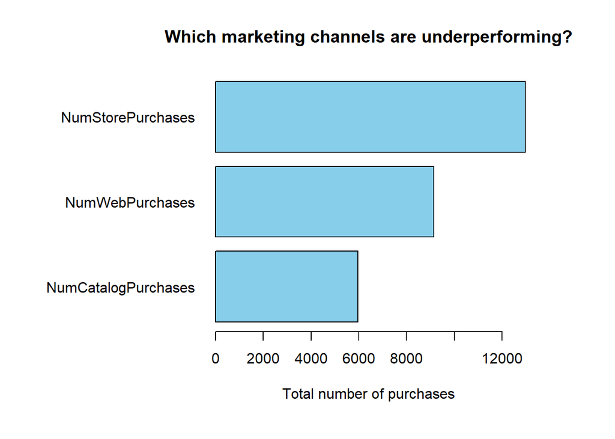

```r
# Select the columns of interest and calculate the sum
purchase_sum <- colSums(new_df[, c("NumWebPurchases", "NumCatalogPurchases", "NumStorePurchases")])

# Sorting the values
purchase_sum <- purchase_sum[order(purchase_sum)]

# Creating the horizontal bar plot

par(mar = c(6, 12, 4, 5) + 0.1)

barplot(purchase_sum,
        horiz = TRUE,
        main = "Which marketing channels are underperforming?",
        xlab = "Total number of purchases",

        col = "skyblue",
        las = 1,
        )
```

The plot above shows that Catalog is the most underperforming channel , while Store purchases is the best performing.

## **3.4 Further Investigation**

- Characteristics: ‘Year_Birth’, ‘Income’, ‘Minorhome’, ‘Country’, ‘Join_month’, ‘Join_weekday’
- Purchase behaviors:
  - Products: ‘MntWines’, ‘MntFruits’, ‘MntMeatProducts’, ‘MntFishProducts’, ‘MntSweetProducts’
  - Channel: ‘NumWebPurchases’, ‘NumCatalogPurchases’, ‘NumStorePurchases’
  - Total: ‘Total_Mnt’, ‘Total_num_purchase’, ‘AOV’

```r
# Creating two groups based on the acceptance of offers
cp_last <- new_df[new_df$Response > 0, ]
cp_the_rest <- new_df[new_df$AcceptedCmp2 == 0, ]

# Getting the number of observations in each group
num_cp_last <- nrow(cp_last)
num_cp_the_rest <- nrow(cp_the_rest)

# Displaying the number of observations in each group
cat("Number of observations in the group that accepted offers from the last campaign:", num_cp_last, "\n")
```

```
## Number of observations in the group that accepted offers from the last campaign: 334
```

```r
cat("Number of observations in the group that did not accept offers from the last campaign:", num_cp_the_rest, "\n")
```

```
## Number of observations in the group that did not accept offers from the last campaign: 2210
```

```r
# Creating a copy of cp__the_rest
cp_the_rest2 <- cp_the_rest

# Find overlapping IDs and remove them from cp_the_rest2
overlap_ids <- intersect(cp_the_rest$ID, cp_last$ID)
cp_the_rest2 <- cp_the_rest2[!cp_the_rest2$ID %in% overlap_ids, ]

# Getting the number of observations in each group after removal of overlaps
num_cp_last <- nrow(cp_last)
num_cp_the_rest <- nrow(cp_the_rest2)

# Displaying the number of observations in each group after removal of overlaps
cat("Number of customers in the group that accepted offers from the last campaign:", num_cp_last, "\n")
```

```
## Number of customers in the group that accepted offers from the last campaign: 334
```

```r
cat("Number of customers in the group that did not accept offers from the last campaign after removal of overlaps:", num_cp_the_rest, "\n")
```

```
## Number of customers in the group that did not accept offers from the last campaign after removal of overlaps: 1896
```

```r
# Select the desired columns for cp_last
cp_last_selected <- cp_last[, c('Year_Birth', 'Income', 'Minorhome', 'Join_month', 'Join_weekday',
                                'MntWines', 'MntFruits', 'MntMeatProducts', 'MntFishProducts', 'MntSweetProducts',
                                'NumWebPurchases', 'NumCatalogPurchases', 'NumStorePurchases',
                                'Total_Mnt', 'Total_num_purchase', 'AOV')]



# Calculate the mean of the selected columns
cp_last_mean <- colMeans(cp_last_selected, na.rm = TRUE)

# Format the mean values for better readability
formatted_cp_last_mean <- format(cp_last_mean, scientific = FALSE)

# Displaying the mean values
cat("This is what an average customer from the last campaign looks like:\n")
```

```
## This is what an average customer from the last campaign looks like:
```

```r
print(formatted_cp_last_mean)
```

```
##          Year_Birth              Income           Minorhome          Join_month
##     " 1969.4161677"     "60029.4071856"     "    0.6467066"     "    6.7395210"
##        Join_weekday            MntWines           MntFruits     MntMeatProducts
##     "    4.0718563"     "  502.7035928"     "   38.2035928"     "  294.3532934"
##     MntFishProducts    MntSweetProducts     NumWebPurchases NumCatalogPurchases
##     "   52.0508982"     "   38.6347305"     "    5.0718563"     "    4.2035928"
##   NumStorePurchases           Total_Mnt  Total_num_purchase                 AOV
##     "    6.0958084"     "  987.3922156"     "   23.0000000"     "   41.8291969"
```

```r
# Select the desired columns for cp_last
cp_the_rest_selected <- cp_the_rest2[, c('Year_Birth', 'Income', 'Minorhome', 'Join_month', 'Join_weekday',
                                'MntWines', 'MntFruits', 'MntMeatProducts', 'MntFishProducts', 'MntSweetProducts',
                                'NumWebPurchases', 'NumCatalogPurchases', 'NumStorePurchases',
                                'Total_Mnt', 'Total_num_purchase', 'AOV')]



# Calculate the mean of the selected columns
cp_the_rest_mean <- colMeans(cp_the_rest_selected, na.rm = TRUE)

# Format the mean values for better readability
formatted_cp_the_rest_mean <- format(cp_the_rest_mean, scientific = FALSE)

# Displaying the mean values
cat("This is what an average customer from the campaign 1-5 looks like:\n")
```

```
## This is what an average customer from the campaign 1-5 looks like:
```

```r
print(formatted_cp_the_rest_mean)
```

```
##          Year_Birth              Income           Minorhome          Join_month
##      " 1968.694093"      "50145.329641"      "    1.004747"      "    6.411392"
##        Join_weekday            MntWines           MntFruits     MntMeatProducts
##      "    4.014768"      "  265.826477"      "   24.308544"      "  144.433544"
##     MntFishProducts    MntSweetProducts     NumWebPurchases NumCatalogPurchases
##      "   35.003165"      "   25.108650"      "    3.915612"      "    2.383966"
##   NumStorePurchases           Total_Mnt  Total_num_purchase                 AOV
##      "    5.723629"      "  535.667722"      "   19.669304"      "   24.110603"
```

```r
# Select the desired columns for cp_last
new_df2_selected <- new_df[, c('Year_Birth', 'Income', 'Minorhome', 'Join_month', 'Join_weekday',
                                'MntWines', 'MntFruits', 'MntMeatProducts', 'MntFishProducts', 'MntSweetProducts',
                                'NumWebPurchases', 'NumCatalogPurchases', 'NumStorePurchases',
                                'Total_Mnt', 'Total_num_purchase', 'AOV')]



# Calculate the mean of the selected columns
new_df2_mean <- colMeans(new_df2_selected, na.rm = TRUE)

# Format the mean values for better readability
formatted_new_df2_mean <- format(new_df2_mean, scientific = FALSE)

# Displaying the mean values
cat("This is what an average customer looks like:\n")
```

```
## This is what an average customer looks like:
```

```r
print(formatted_new_df2_mean)
```

```
##          Year_Birth              Income           Minorhome          Join_month
##     " 1968.8058036"     "51687.4593750"     "    0.9504464"     "    6.4674107"
##        Join_weekday            MntWines           MntFruits     MntMeatProducts
##     "    4.0272321"     "  303.9357143"     "   26.3022321"     "  166.9500000"
##     MntFishProducts    MntSweetProducts     NumWebPurchases NumCatalogPurchases
##     "   37.5254464"     "   27.0629464"     "    4.0848214"     "    2.6620536"
##   NumStorePurchases           Total_Mnt  Total_num_purchase                 AOV
##     "    5.7901786"     "  605.7982143"     "   20.1785714"     "   26.8624481"
```

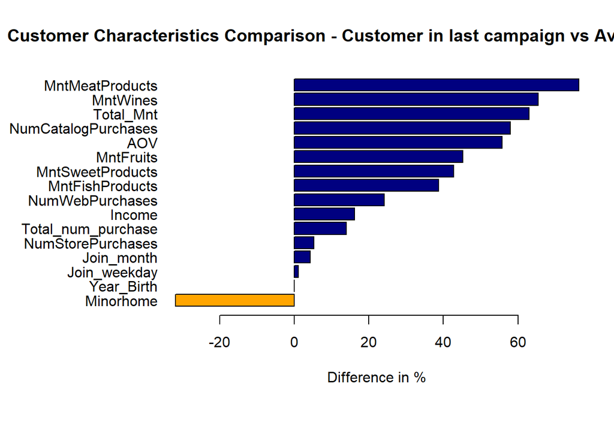

```r
# Calculate the percentage differences
percentage_diff <- ((colMeans(cp_last_selected, na.rm = TRUE) - colMeans(new_df2_selected, na.rm = TRUE)) / colMeans(new_df2_selected, na.rm = TRUE)) * 100

# Remove NA values
percentage_diff <- percentage_diff[!is.na(percentage_diff)]

# Sort the values
percentage_diff_sorted <- sort(percentage_diff)

# Determine colors
colors <- ifelse(percentage_diff_sorted >= 0, "navy", "orange")

# Create a bar plot
par(mar = c(7, 10, 4, 2)) #margins (bottom, left, top, right)

barplot(percentage_diff_sorted, horiz = TRUE, col = colors, main = "Customer Characteristics Comparison - Customer in last campaign vs Average customer",
      xlab = "Difference in %", names.arg = names(percentage_diff_sorted), las = 1)
```

The plot above shows the comparison between the customers in the last campaign and the average customer

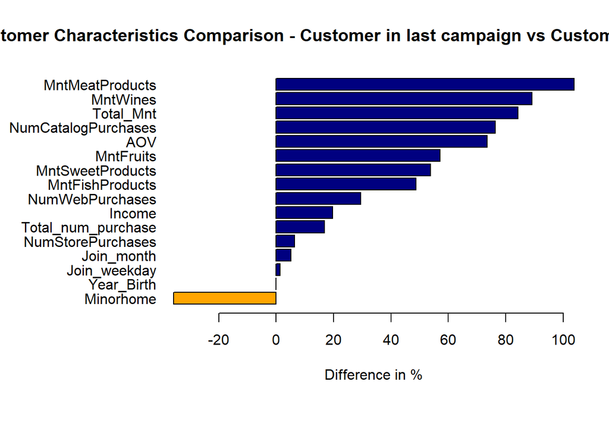

```r
# Calculate the percentage differences
percentage_diff2 <- ((colMeans(cp_last_selected, na.rm = TRUE) - colMeans(cp_the_rest_selected, na.rm = TRUE)) / colMeans(cp_the_rest_selected, na.rm = TRUE)) * 100

# Remove NA values
percentage_diff2 <- percentage_diff2[!is.na(percentage_diff2)]

# Sort the values
percentage_diff_sorted2 <- sort(percentage_diff2)

# Determine colors
colors <- ifelse(percentage_diff_sorted2 >= 0, "navy", "orange")

# Create a bar plot
par(mar = c(7, 10, 4, 2)) #margins (bottom, left, top, right)

barplot(percentage_diff_sorted2, horiz = TRUE, col = colors, main = "Customer Characteristics Comparison - Customer in last campaign vs Customers in Campaign 1-5",
      xlab = "Difference in %",  names.arg = names(percentage_diff_sorted), las = 1)
```

Let’s look into the location of campaigns

```r
# Counting the occurrences of each country
country_counts <- table(new_df$Country)

# Displaying the counts
print(country_counts)
```

```
##
##  AUS   CA  GER  IND   ME   SA   SP   US
##  160  268  120  148    3  337 1095  109
```

```r
cp_last_country <- cp_last %>%
  group_by(Country) %>%
  summarise(Percent = n() / nrow(cp_last) * 100) %>%
  arrange(Country)

# Print the resulting dataframe
print(cp_last_country)
```

```
## # A tibble: 8 × 2
##   Country Percent
##   <chr>     <dbl>
## 1 AUS       6.89
## 2 CA       11.4
## 3 GER       5.09
## 4 IND       3.89
## 5 ME        0.599
## 6 SA       15.6
## 7 SP       52.7
## 8 US        3.89
```

```r
cp_the_rest2_country <- cp_the_rest2 %>%
  group_by(Country) %>%
  summarise(Percent = n() / nrow(cp_the_rest2) * 100) %>%
  arrange(Country)

# Print the resulting dataframe
print(cp_the_rest2_country)
```

```
## # A tibble: 8 × 2
##   Country Percent
##   <chr>     <dbl>
## 1 AUS      7.23
## 2 CA      12.1
## 3 GER      5.33
## 4 IND      7.07
## 5 ME       0.0527
## 6 SA      14.9
## 7 SP      48.3
## 8 US       5.06
```

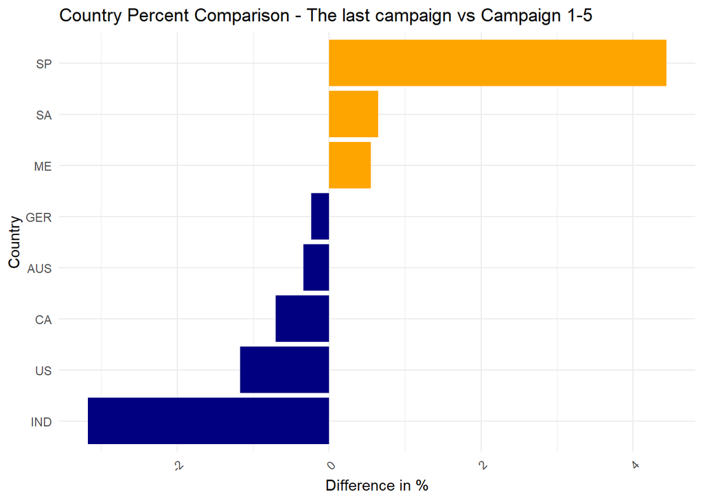

```r
# Calculate the difference in percentages between cp_last_country and cp__the_rest2_country
country_final <- merge(cp_last_country, cp_the_rest2_country, by = "Country", suffixes = c("_cp_last", "_cp_rest"))
country_final$Difference <- country_final$Percent_cp_last - country_final$Percent_cp_rest

# Visualize the differences
library(ggplot2)
ggplot(country_final, aes(x = reorder(Country, Difference), y = Difference, fill = Difference > 0)) +
  geom_bar(stat = "identity") +
  scale_fill_manual(values = c("navy", "orange"), labels = c("Positive", "Negative")) +
  labs(title = "Country Percent Comparison - The last campaign vs Campaign 1-5",
       x = "Country",
       y = "Difference in %") +
  theme_minimal() +
  theme(axis.text.x = element_text(angle = 45, hjust = 1)) +
  guides(fill = FALSE) +
  coord_flip()
```

Looking at the proportion change of each country from the previous campaigns to the most successful campaign, we can see that Spain has relatively more customers (+4%), and India has fewer customers (-3%) attracted to the last campaign.

```r
# List of columns
list <- c('MntWines', 'MntMeatProducts', 'MntGoldProds', 'MntFishProducts', 'MntFruits', 'MntSweetProducts')

# Loop through each column
for (i in list) {
  # Calculate Pearson correlation coefficient and p-value
  result <- cor.test(x = new_df[[i]], y = new_df$Total_accept, method = "pearson")

  # Print results
  cat(i, "vs Total_accept:\n")
  cat('Pearson correlation (r): ', result$estimate, '\n')
  cat('Pearson p-value: ', result$p.value, '\n\n')
}
```

```
## MntWines vs Total_accept:
## Pearson correlation (r):  0.4790233
## Pearson p-value:  7.373568e-129
##
## MntMeatProducts vs Total_accept:
## Pearson correlation (r):  0.3014178
## Pearson p-value:  2.868272e-48
##
## MntGoldProds vs Total_accept:
## Pearson correlation (r):  0.1911584
## Pearson p-value:  7.074937e-20
##
## MntFishProducts vs Total_accept:
## Pearson correlation (r):  0.1595641
## Pearson p-value:  3.043495e-14
##
## MntFruits vs Total_accept:
## Pearson correlation (r):  0.1503584
## Pearson p-value:  8.490945e-13
##
## MntSweetProducts vs Total_accept:
## Pearson correlation (r):  0.1784635
## Pearson p-value:  1.73749e-17
```

These results suggest that the amount spent on various product categories (wines, meat products, gold products, fish products, fruits, and sweet products) is positively correlated with the total acceptance of campaign offers, with wines showing the strongest correlation followed by meat products. However, the strength of these correlations varies, and all are statistically significant.

## **Section 04: Formulating data-driven Solutions**

*First, let’s review the main goal of this project*

I’m a data analyst, and the Chief Marketing Officer has told me that previous marketing campaigns have not been as effective as they were expected to be. I need to analyze the data set to understand this problem and propose data-driven solutions.

To form data-driven solutions, I first summarize all the insights I got from the analytics, then I use those insights to form actionable strategies.

## **Actionable Data-Driven Solutions**

### **On Increasing revenue:**

- Implement marketing campaigns targeted at converting customers who predominantly shop online or through catalogs into in-store purchasers, as in-store purchases typically yield higher average order volumes.
- Additionally, establish a loyalty program aimed at cultivating long-term loyalty among high-income customers, incentivizing them to remain loyal to the brand over time.

Thank you for reading to the end! If you are interested in the full code of this project, please check out my [Github](https://github.com/joshuaagbroko) .